# Baseball Data Exploration by James Kelly

# Project Summary

For this project I intend to explore the relationship between player size (height and weight) and several batting statistics (batting average and home runs). As interesting relationships emerge I will explore them in greater detail!

# Data Summary

```
## [1] 871  13
```

```
## 'data.frame':    871 obs. of  13 variables:
##  $ name      : Factor w/ 869 levels "Adolfo Phillips",..: 225 453 489 710 701 827 537 109 646 822 ...
##  $ handedness: Factor w/ 3 levels "B","L","R": 3 2 3 3 3 2 3 3 3 3 ...
##  $ height    : int  73 71 70 73 73 72 73 72 72 74 ...
##  $ weight    : int  182 175 150 180 180 183 175 170 176 190 ...
##  $ avg       : num  0.13 0.263 0.275 0.241 0.195 0.246 0.286 0.231 0.244 0.226 ...
##  $ HR        : int  4 27 138 6 15 75 91 6 8 12 ...
##  $ BMI       : num  24 24.4 21.5 23.7 23.7 ...
##  $ rand      : num  0.33 0.23 0.24 -0.41 -0.34 -0.2 -0.31 0.12 0.42 0.48 ...
##  $ adj_BMI   : num  24.3 24.6 21.8 23.3 23.4 ...
##  $ power     : num  30.8 102.7 501.8 24.9 76.9 ...
##  $ log10HR   : num  0.602 1.431 2.14 0.778 1.176 ...
##  $ lm        : num  1.39 1.42 1.2 1.37 1.37 ...
##  $ range     : Factor w/ 2 levels "healthy","overweight": 1 1 1 1 1 1 1 1 1 1 ...
```

```
##  [1] "name"       "handedness" "height"     "weight"     "avg"
##  [6] "HR"         "BMI"        "rand"       "adj_BMI"    "power"
## [11] "log10HR"    "lm"         "range"
```

# Data Cleaning

I intend to remove players that do not have at least one home run. This way I can focus on players that are more likely to have many at-bats at the major league level, and have demonstrated at least some ability as a power hitter.

I will then create a statistic for body mass index (BMI). I suspect that BMI will have a positive relationship with home runs, and an inverse relationship with batting average. I expect higher BMI–> more HR, lower BMI–> more avg

# Univariate Plots

```
## stat_bin: binwidth defaulted to range/30. Use 'binwidth = x' to adjust this.
```

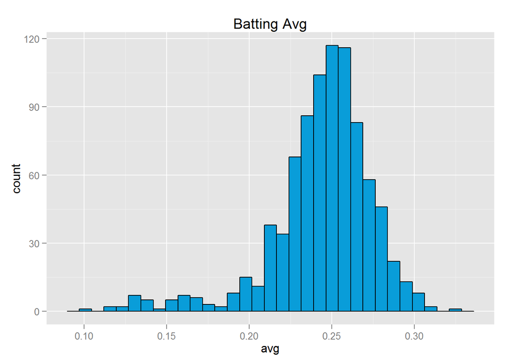

```
## stat_bin: binwidth defaulted to range/30. Use 'binwidth = x' to adjust this.
```

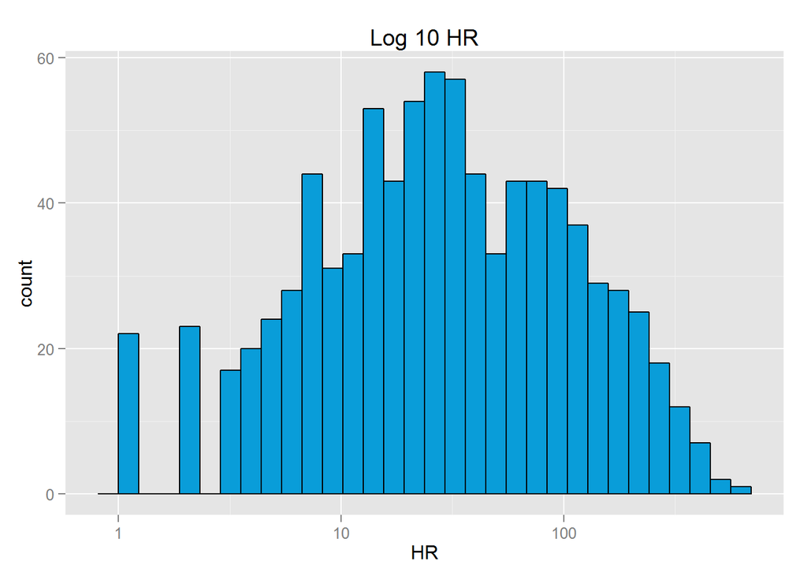

```
## stat_bin: binwidth defaulted to range/30. Use 'binwidth = x' to adjust this.
```

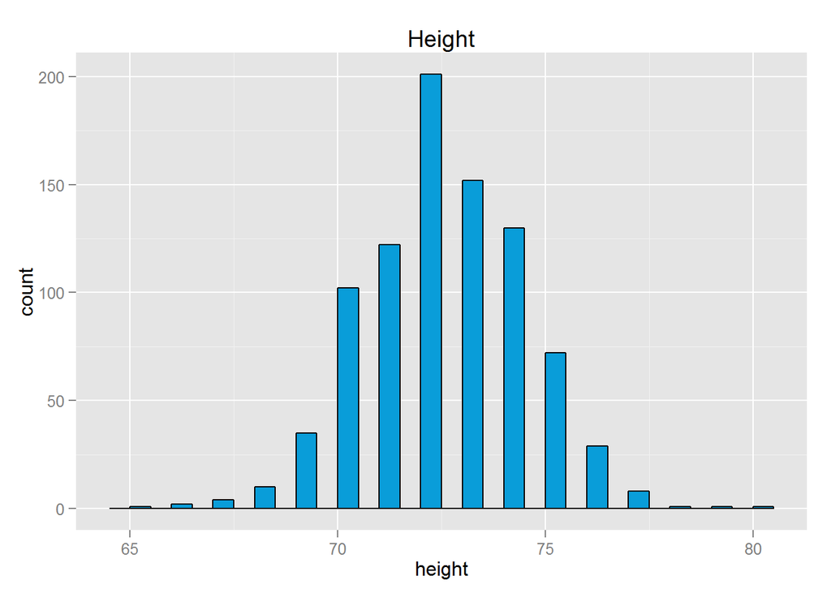

```
## stat_bin: binwidth defaulted to range/30. Use 'binwidth = x' to adjust this.
```

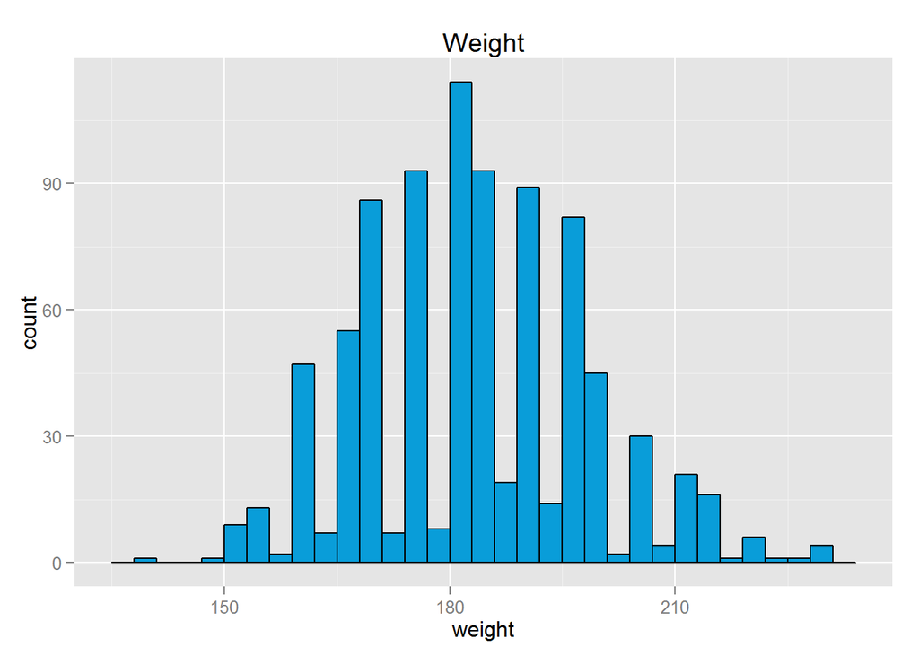

[figure not shown]

```
## stat_bin: binwidth defaulted to range/30. Use 'binwidth = x' to adjust this.
```

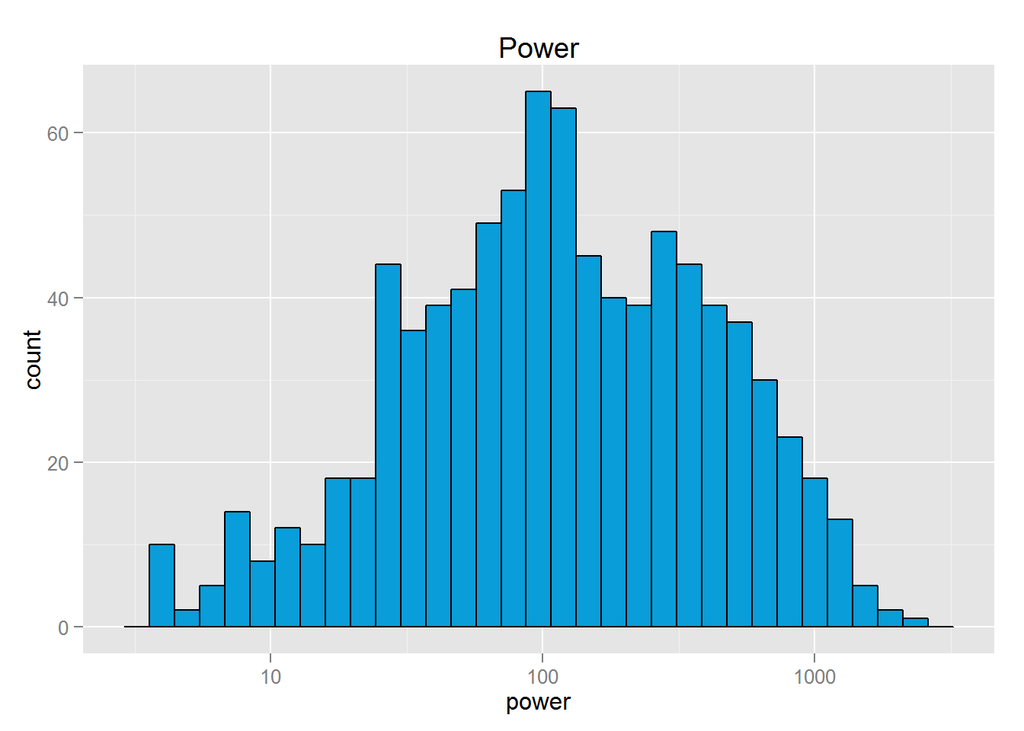

# Bivariate Plots

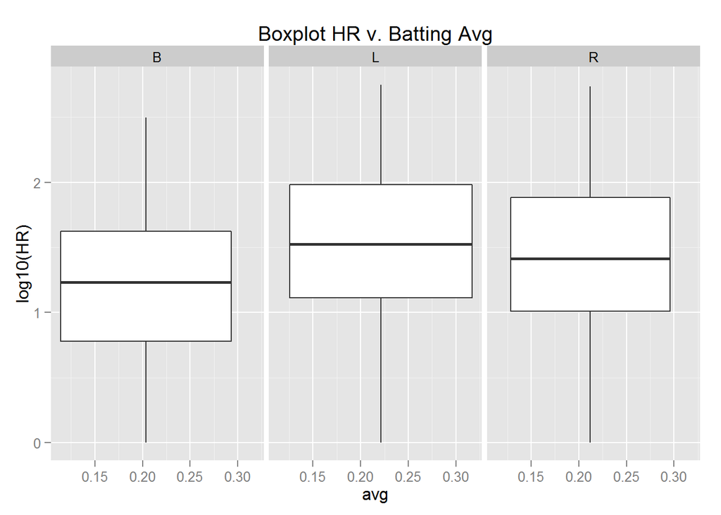

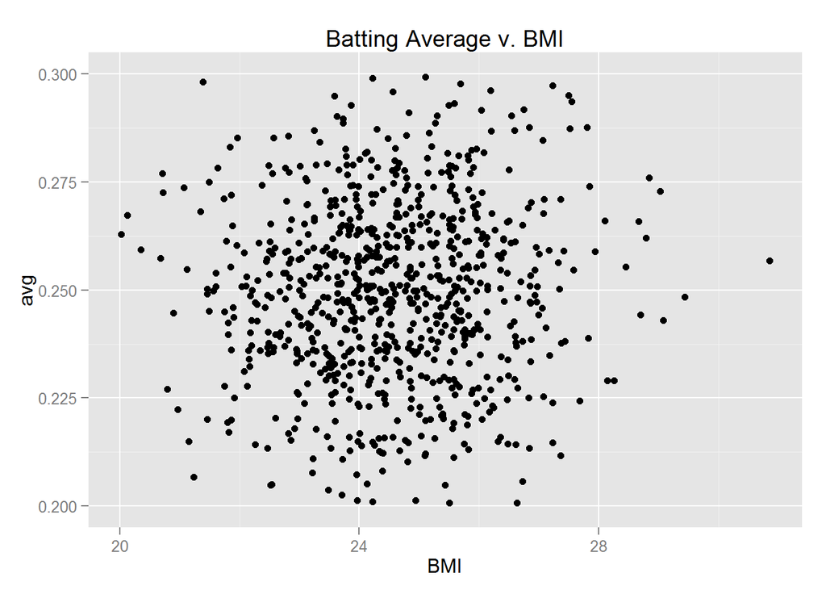

```
##
##  Pearson's product-moment correlation
##
## data:  baseball_data$BMI and baseball_data$avg
## t = -0.14346, df = 869, p-value = 0.886
## alternative hypothesis: true correlation is not equal to 0
## 95 percent confidence interval:
##  -0.07127113  0.06158083
## sample estimates:
##          cor
## -0.004866629
```

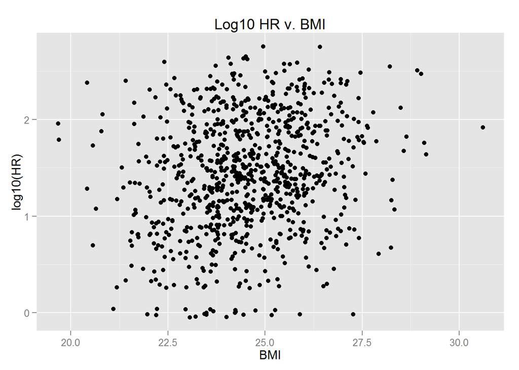

```
##
##  Pearson's product-moment correlation
##
## data:  baseball_data$BMI and log10(baseball_data$HR)
## t = 5.9868, df = 869, p-value = 3.129e-09
## alternative hypothesis: true correlation is not equal to 0
## 95 percent confidence interval:
##  0.1343730 0.2619879
## sample estimates:
##      cor
## 0.199024
```

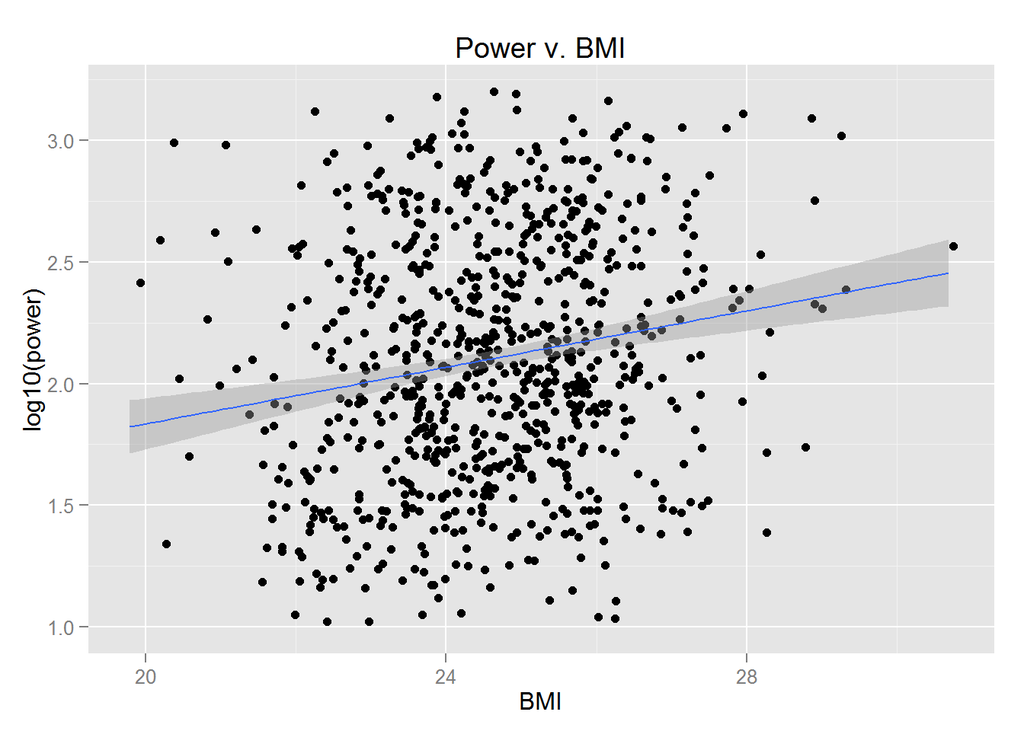

```
##
##  Pearson's product-moment correlation
##
## data:  baseball_data$BMI and log10(baseball_data$power)
## t = 6.3853, df = 869, p-value = 2.783e-10
## alternative hypothesis: true correlation is not equal to 0
## 95 percent confidence interval:
##  0.1473401 0.2742664
## sample estimates:
##       cor
## 0.2116957
```

First I created a boxplot to took a look at the relationship between batting average and home runs, and faceted the data by handedness. I was surprised to learn that lefties seem to have a higher batting average and more home runs, while switch hitters struggle!

Next I looked at the relationships between BMI and batting average, and BMI and home runs. Using a scatterplot I noticed that there does not appear to be any relationship between BMI and batting average. This was confirmed through correlations analysis which revealed an r quared near zero.

Next, I attempted to create a metric to capture hitters’ power. There are already MLB statistics that measure this, but unfortunately they were not included in the data. Instead, I added a new column to the dataframe, labeled “power” which is home runs divided by batting average. This is not a very robust statistic, but it may be helpful in measuring the relationship between BMI and hitting.

Indeed, after creating another scatterplot between BMI and “power” there does to a relationship between the two variables. A pearson test the relationship is slightly stronger than that between BMI and home runs, but the “power” variable is a bit odd so I will not pursue this much further.

Based on feedback from reviewers, I will bin BMI based on how healthy their bodyweight is.

```r
baseball_data$range <- ifelse(baseball_data$BMI < 25, 'healthy', 'overweight')

baseball_data$range <- ordered(baseball_data$range,
                     levels = c('healthy', 'overweight'))
summary(baseball_data$range)
```

```
##    healthy overweight
##        502        369
```

# Multivariate Plots

```
## geom_smooth: method="auto" and size of largest group is <1000, so using loess. Use 'method = x' to change the smoothing method.
```

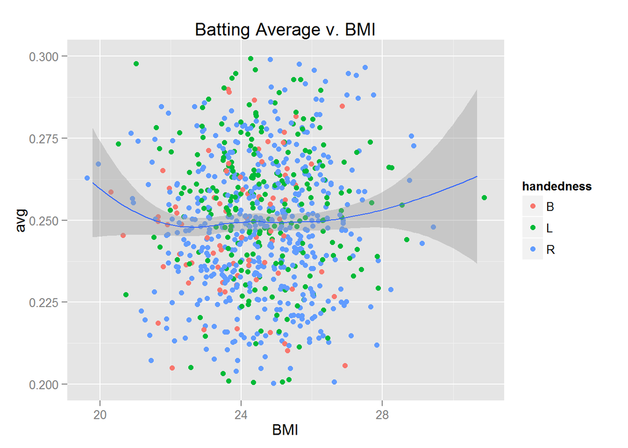

```
## geom_smooth: method="auto" and size of largest group is <1000, so using loess. Use 'method = x' to change the smoothing method.
```

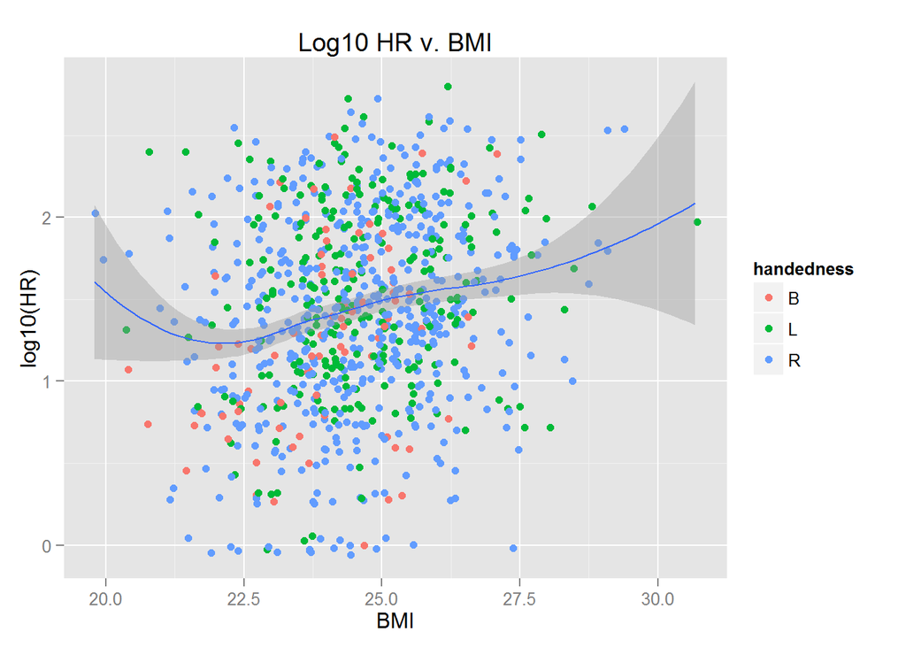

```
## geom_smooth: method="auto" and size of largest group is <1000, so using loess. Use 'method = x' to change the smoothing method.
```

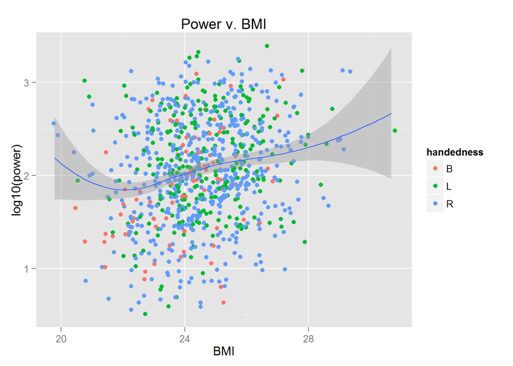

```
##
## Call:
## lm(formula = log10HR ~ BMI, data = baseball_data)
##
## Coefficients:
## (Intercept)          BMI
##    -0.46399      0.07736
```

In this section, I created the same plots as those in the bivariate plots section, but included the handedness variable. I had hoped the superiority of lefties and inferiority of switch hitters would be more clear, but unfortunately it was not. I will instead color the plots by the range variable.

```
## geom_smooth: method="auto" and size of largest group is <1000, so using loess. Use 'method = x' to change the smoothing method.
```

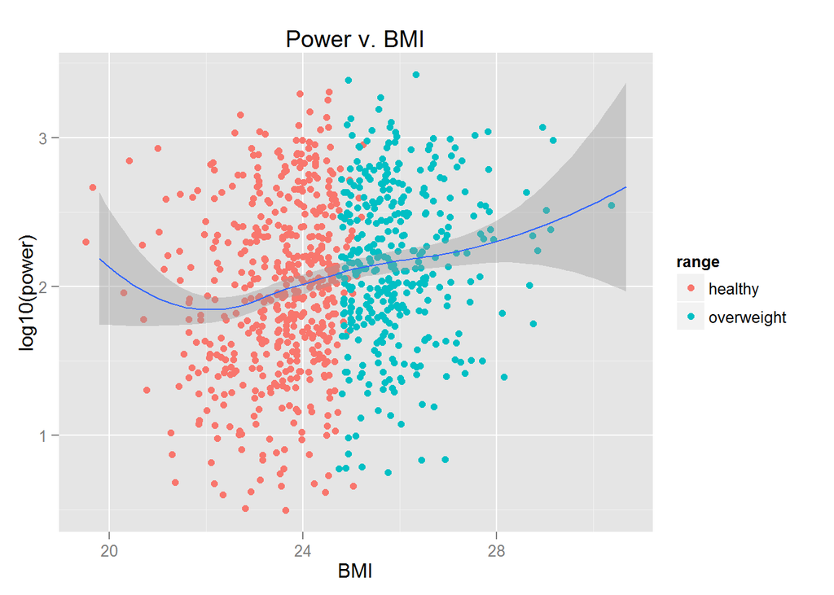

```r
ggplot(aes(x = BMI, y = log10(power)),
       data = baseball_data) +
  geom_point(aes(color = range),
             position = position_jitter(h = 0.1, w = 0.3)) +
  geom_smooth() +
  ggtitle('Power v. BMI')
```

# Export to CSV

write.csv(baseball_data, file = “C:/Users/jkelly/Desktop/Data Viz/baseball_data_final.csv”, row.names=FALSE)